# R Notebook

## Packages

```r
library(MASS) # for Box-Cox, later
library(tidyverse)
library(broom)
```

## The sleep data

Read in and check

```r
my_url="http://www.utsc.utoronto.ca/~butler/d29/sleep.txt"
sleep=read_delim(my_url," ")
sleep
```

| atst | age |
| --- | --- |
| 586.00 | 4.40 |
| 461.75 | 14.00 |
| 491.10 | 10.10 |
| 565.00 | 6.70 |
| 462.00 | 11.50 |
| 532.10 | 9.60 |
| 477.60 | 12.40 |
| 515.20 | 8.90 |
| 493.00 | 11.10 |
| 528.30 | 7.75 |

[output cut: 3 more lines]

Two quantitative variables: scatterplot

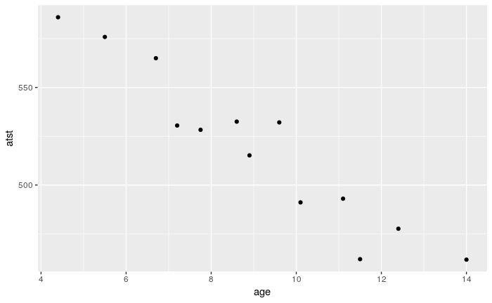

```r
ggplot(sleep,aes(x=age,y=atst))+geom_point()
```

Correlation, two ways:

just the correlation as a number

```r
with(sleep,cor(atst,age))
```

```
[1] -0.9515469
```

Correlation matrix

```r
cor(sleep)
```

```
           atst        age
atst  1.0000000 -0.9515469
age  -0.9515469  1.0000000
```

shows correlation of each pair of variables (including variables with themselves: 1)

Add a smooth trend to the scatterplot

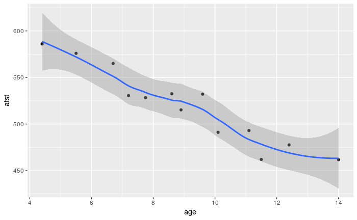

```r
ggplot(sleep,aes(x=age,y=atst))+geom_point()+
  geom_smooth()
```

This looks pretty straight. Fit a regression.

```r
sleep.1=lm(atst~age,data=sleep)
summary(sleep.1)
```

```
Call:
lm(formula = atst ~ age, data = sleep)

Residuals:
    Min      1Q  Median      3Q     Max
-23.011  -9.365   2.372   6.770  20.411

Coefficients:
            Estimate Std. Error t value Pr(>|t|)
(Intercept)  646.483     12.918   50.05 2.49e-14 ***
age          -14.041      1.368  -10.26 5.70e-07 ***
---
Signif. codes:  0 ‘***’ 0.001 ‘**’ 0.01 ‘*’ 0.05 ‘.’ 0.1 ‘ ’ 1

Residual standard error: 13.15 on 11 degrees of freedom
Multiple R-squared:  0.9054,    Adjusted R-squared:  0.8968
F-statistic: 105.3 on 1 and 11 DF,  p-value: 5.7e-07
```

Note:

- high R-squared (regression fits well)
- low P-values for slope and on F-test (a straight line fits way better than chance)
- slope for `age` negative, so as age goes up, average total sleep time goes down.

`summary` output for looking at, but hard to do anything else with. Package `broom` produces data frame output so can do with it whatever we can do with data frames.

To look:

```r
glance(sleep.1)
```

| r.squared | adj.r.squared | sigma | statistic | p.value | df | logLik | AIC | BIC | deviance | df.residual |
| --- | --- | --- | --- | --- | --- | --- | --- | --- | --- | --- |
| 0.9054416 | 0.8968454 | 13.15238 | 105.3302 | 5.700014e-07 | 2 | -50.85618 | 107.7124 | 109.4072 | 1902.835 | 11 |

One-line summary of whole model, including R-squared, F-statistic and its P-value.

```r
tidy(sleep.1)
```

| term | estimate | std.error | statistic | p.value |
| --- | --- | --- | --- | --- |
| (Intercept) | 646.48334 | 12.917726 | 50.04622 | 2.490578e-14 |
| age | -14.04105 | 1.368116 | -10.26305 | 5.700014e-07 |

Table of intercept/slopes including their values and P-values.

Eg. just the `age` line:

```r
tidy(sleep.1) %>% filter(term=="age")
```

| term | estimate | std.error | statistic | p.value |
| --- | --- | --- | --- | --- |
| age | -14.04105 | 1.368116 | -10.26305 | 5.700014e-07 |

or just the term and p-value columns:

```r
tidy(sleep.1) %>% select(term, p.value)
```

| term | p.value |
| --- | --- |
| (Intercept) | 2.490578e-14 |
| age | 5.700014e-07 |

To add regression quantities to original data:

```r
sleep.1 %>% augment(sleep)
```

| atst | age | .fitted | .se.fit | .resid | .hat | .sigma | .cooksd | .std.resid |
| --- | --- | --- | --- | --- | --- | --- | --- | --- |
| 586.00 | 4.40 | 584.7027 | 7.342500 | 1.297271 | 0.31165883 | 13.78546 | 0.003199595 | 0.1188843 |
| 461.75 | 14.00 | 449.9087 | 7.682869 | 11.841335 | 0.34122311 | 12.99996 | 0.318657829 | 1.1092444 |
| 491.10 | 10.10 | 504.6688 | 3.916632 | -13.568753 | 0.08867826 | 13.04151 | 0.056821825 | -1.0806868 |
| 565.00 | 6.70 | 552.4083 | 4.869396 | 12.591682 | 0.13706979 | 13.11145 | 0.084356677 | 1.0306037 |
| 462.00 | 11.50 | 485.0113 | 4.946841 | -23.011286 | 0.14146448 | 11.34048 | 0.293747511 | -1.8882414 |
| 532.10 | 9.60 | 511.6893 | 3.722501 | 20.410722 | 0.08010529 | 12.04143 | 0.113989080 | 1.6180245 |
| 477.60 | 12.40 | 472.3743 | 5.849428 | 5.225658 | 0.19779641 | 13.67039 | 0.024260104 | 0.4436029 |
| 515.20 | 8.90 | 521.5180 | 3.654187 | -6.318011 | 0.07719214 | 13.63664 | 0.010458584 | -0.5000582 |
| 493.00 | 11.10 | 490.6277 | 4.594955 | 2.372295 | 0.12205460 | 13.77107 | 0.002575835 | 0.1925000 |
| 528.30 | 7.75 | 537.6652 | 4.062921 | -9.365217 | 0.09542636 | 13.43829 | 0.029564990 | -0.7486721 |

[output cut: 3 more lines]

this permits eg. plots of residuals against x’s:

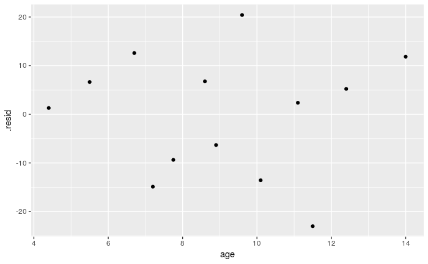

```r
sleep.1 %>% augment(sleep) %>%
  ggplot(aes(x=age, y=.resid))+geom_point()
```

which looks pretty random.

## Predictions for the sleep data

Predict average total sleep time for ages 5 and 10.

First, create data frame with column called `age` with the values we want to predict for.

```r
my.age=c(10,5)
ages.new=tibble(age=my.age)
ages.new
```

| age |
| --- |
| 10 |
| 5 |

Two types of prediction in regression (slide 25).

Confidence interval for mean response

|  | age | fit | lwr | upr |
| --- | --- | --- | --- | --- |
| 1 | 10 | 506.0729 | 497.5574 | 514.5883 |
| 2 | 5 | 576.2781 | 561.6578 | 590.8984 |

Prediction interval for response of new observation

```r
pp=predict(sleep.1,ages.new,interval="p")
cbind(ages.new,pp)
```

|  | age | fit | lwr | upr |
| --- | --- | --- | --- | --- |
| 1 | 10 | 506.0729 | 475.8982 | 536.2475 |
| 2 | 5 | 576.2781 | 543.8474 | 608.7088 |

Put these next to the data they’re predictions for:

```r
cbind(ages.new,pc)
```

|  | age | fit | lwr | upr |
| --- | --- | --- | --- | --- |
| 1 | 10 | 506.0729 | 497.5574 | 514.5883 |
| 2 | 5 | 576.2781 | 561.6578 | 590.8984 |

and

```r
cbind(ages.new,pp)
```

|  | age | fit | lwr | upr |
| --- | --- | --- | --- | --- |
| 1 | 10 | 506.0729 | 475.8982 | 536.2475 |
| 2 | 5 | 576.2781 | 543.8474 | 608.7088 |

That grey envelope on a plot with fitted line:

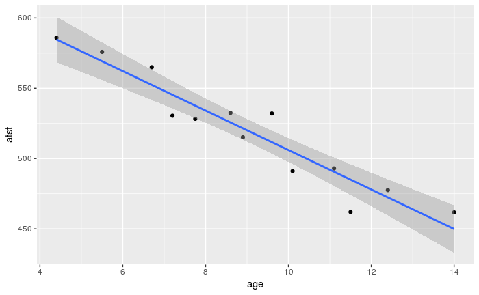

```r
ggplot(sleep,aes(x=age,y=atst))+geom_point()+
  geom_smooth(method="lm")
```

Let’s tweak the y-scale so we can see what that “envelope” is:

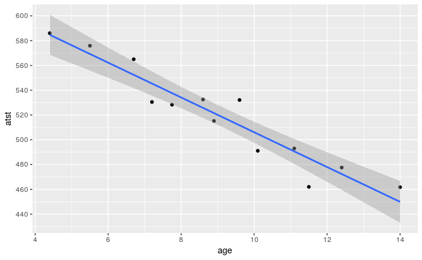

```r
ggplot(sleep,aes(x=age,y=atst))+geom_point()+
  geom_smooth(method="lm")+
  scale_y_continuous(breaks=seq(420,600,20))
```

At age 5, from about 560 to 590 At age 10, from about 497 to 515.

These are the confidence interval for the mean response (of all children aged 5, 10 respectively).

Technical note: what kind of things are those predictions?

```r
pc
```

```
       fit      lwr      upr
1 506.0729 497.5574 514.5883
2 576.2781 561.6578 590.8984
```

```r
class(pc)
```

```
[1] "matrix"
```

Before we used `cbind` that works with matrices:

```r
cbind(ages.new, pc)
```

|  | age | fit | lwr | upr |
| --- | --- | --- | --- | --- |
| 1 | 10 | 506.0729 | 497.5574 | 514.5883 |
| 2 | 5 | 576.2781 | 561.6578 | 590.8984 |

This does not work, because `pc` is not a data frame:

```r
bind_cols(ages.new, pc)
```

```
Error in cbind_all(x) : Argument 2 must have names
```

Alternatively, make `pc` into a tibble and then use `tidyverse` tools:

```r
as_tibble(pc) %>% bind_cols(ages.new)
```

| fit | lwr | upr | age |
| --- | --- | --- | --- |
| 506.0729 | 497.5574 | 514.5883 | 10 |
| 576.2781 | 561.6578 | 590.8984 | 5 |

Last, residual plot (vs fitted values):

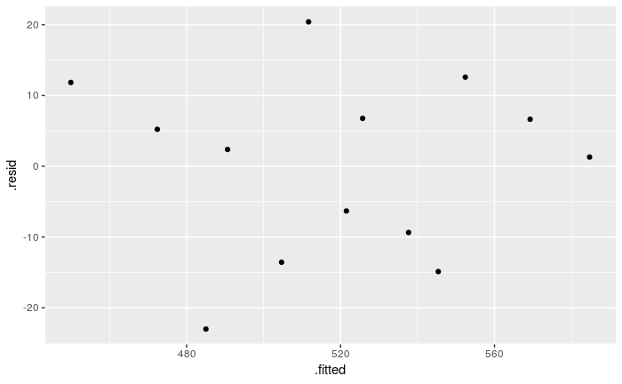

No patterns here. Good.

## A bad data set

```r
my_url="http://www.utsc.utoronto.ca/~butler/d29/curvy.txt"
curvy=read_delim(my_url," ")
curvy
```

| xx | yy |
| --- | --- |
| 0 | 4 |
| 1 | 7 |
| 2 | 10 |
| 3 | 12 |
| 4 | 15 |
| 5 | 16 |
| 6 | 15 |
| 7 | 14 |
| 8 | 13 |
| 9 | 14 |

Make a scatterplot:

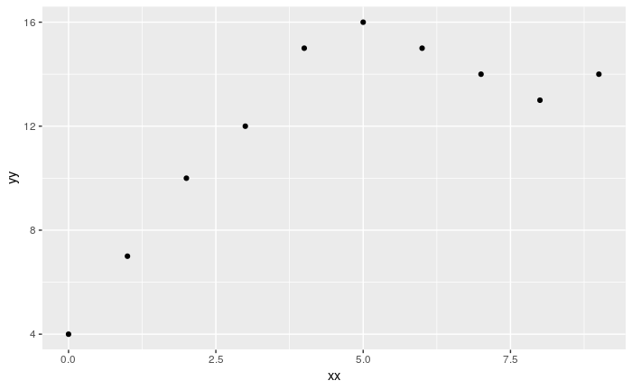

```r
ggplot(curvy,aes(x=xx,y=yy))+geom_point()
```

not linear! Increases and then levels off.

A straight line should be bad, but try one anyway:

```r
curvy.1=lm(yy~xx,data=curvy)
summary(curvy.1)
```

```
Call:
lm(formula = yy ~ xx, data = curvy)

Residuals:
   Min     1Q Median     3Q    Max
-3.582 -2.204  0.000  1.514  3.509

Coefficients:
            Estimate Std. Error t value Pr(>|t|)
(Intercept)   7.5818     1.5616   4.855  0.00126 **
xx            0.9818     0.2925   3.356  0.00998 **
---
Signif. codes:  0 ‘***’ 0.001 ‘**’ 0.01 ‘*’ 0.05 ‘.’ 0.1 ‘ ’ 1

Residual standard error: 2.657 on 8 degrees of freedom
Multiple R-squared:  0.5848,    Adjusted R-squared:  0.5329
F-statistic: 11.27 on 1 and 8 DF,  p-value: 0.009984
```

this looks not so bad: moderately high R-squared and significantly positive slope. But:

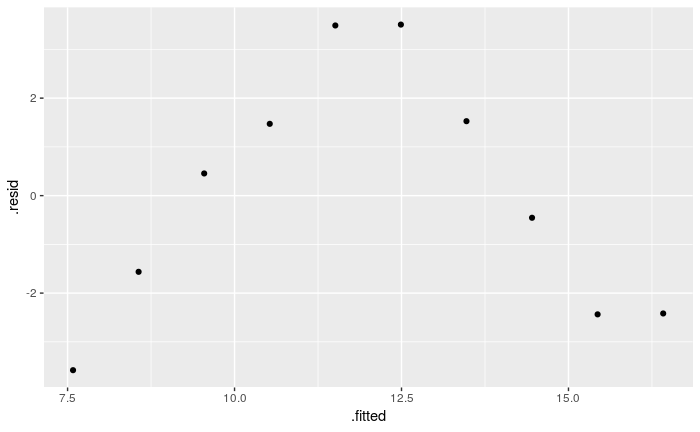

```r
ggplot(curvy.1,aes(x=.fitted,y=.resid))+geom_point()
```

curved, so original relationship curved. Try adding an x-squared term. Two ways to get to the same place:

```r
curvy.2=lm(yy~xx+I(xx^2),data=curvy)
curvy.2a=update(curvy.1,.~.+I(xx^2))
```

with results (`summary(curvy.2a)` same):

```r
summary(curvy.2)
```

```
Call:
lm(formula = yy ~ xx + I(xx^2), data = curvy)

Residuals:
    Min      1Q  Median      3Q     Max
-1.2091 -0.3602 -0.2364  0.8023  1.2636

Coefficients:
            Estimate Std. Error t value Pr(>|t|)
(Intercept)  3.90000    0.77312   5.045 0.001489 **
xx           3.74318    0.40006   9.357 3.31e-05 ***
I(xx^2)     -0.30682    0.04279  -7.170 0.000182 ***
---
Signif. codes:  0 ‘***’ 0.001 ‘**’ 0.01 ‘*’ 0.05 ‘.’ 0.1 ‘ ’ 1

Residual standard error: 0.9833 on 7 degrees of freedom
Multiple R-squared:  0.9502,    Adjusted R-squared:  0.936
F-statistic: 66.83 on 2 and 7 DF,  p-value: 2.75e-05
```

R-squared is much improved, and squared term is strongly significant (worth adding).

How are the residuals?

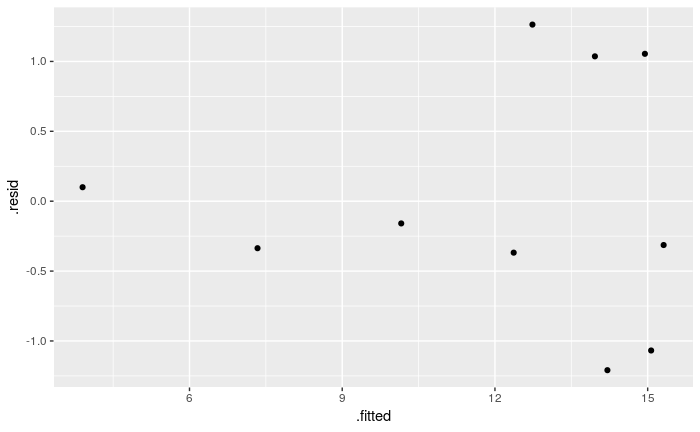

```r
ggplot(curvy.2,aes(x=.fitted,y=.resid))+geom_point()
```

Not curved any more, at least.

Scatterplot with fitted curve? Uses values from original data plus regression, so use `augment` to create data frame with both:

```r
curvy.2 %>% augment(curvy)
```

| xx | yy | .fitted | .se.fit | .resid | .hat | .sigma | .cooksd | .std.resid |
| --- | --- | --- | --- | --- | --- | --- | --- | --- |
| 0 | 4 | 3.900000 | 0.7731168 | 0.1000000 | 0.6181818 | 1.0600308 | 0.014618667 | 0.1645829 |
| 1 | 7 | 7.336364 | 0.5191871 | -0.3363636 | 0.2787879 | 1.0497068 | 0.020905988 | -0.4028010 |
| 2 | 10 | 10.159091 | 0.4210248 | -0.1590909 | 0.1833333 | 1.0596533 | 0.002398542 | -0.1790342 |
| 3 | 12 | 12.368182 | 0.4347203 | -0.3681818 | 0.1954545 | 1.0487844 | 0.014111528 | -0.4174458 |
| 4 | 15 | 13.963636 | 0.4656353 | 1.0363636 | 0.2242424 | 0.9472473 | 0.137973229 | 1.1966363 |
| 5 | 16 | 14.945455 | 0.4656353 | 1.0545455 | 0.2242424 | 0.9429262 | 0.142856862 | 1.2176299 |
| 6 | 15 | 15.313636 | 0.4347203 | -0.3136364 | 0.1954545 | 1.0524509 | 0.010240053 | -0.3556019 |
| 7 | 14 | 15.068182 | 0.4210248 | -1.0681818 | 0.1833333 | 0.9461346 | 0.108130175 | -1.2020867 |
| 8 | 13 | 14.209091 | 0.5191871 | -1.2090909 | 0.2787879 | 0.8889297 | 0.270128578 | -1.4479063 |
| 9 | 14 | 12.736364 | 0.7731168 | 1.2636364 | 0.6181818 | 0.6565246 | 2.334274983 | 2.0797294 |

and then

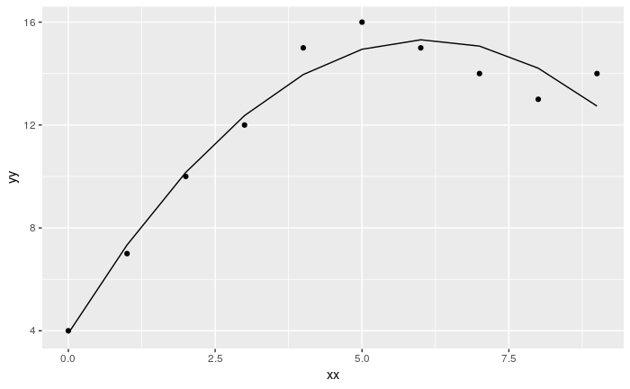

```r
curvy.2 %>% augment(curvy) %>%
  ggplot(aes(x=xx, y=yy))+geom_point()+
  geom_line(aes(y=.fitted))
```

this is a definite improvement over the line.

## Box and Cox (see slide 40)

Uses package `MASS`.

Some more data:

```r
my_url="http://www.utsc.utoronto.ca/~butler/d29/madeup.csv"
madeup=read_csv(my_url)
madeup
```

| row | x | y |
| --- | --- | --- |
| 1 | 0 | 17.92576 |
| 2 | 1 | 33.58480 |
| 3 | 2 | 82.69371 |
| 4 | 3 | 31.19415 |
| 5 | 4 | 177.07919 |
| 6 | 5 | 358.70001 |
| 7 | 6 | 469.30232 |
| 8 | 7 | 583.24106 |

Scatterplot:

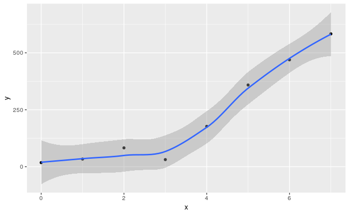

```r
ggplot(madeup,aes(x=x,y=y))+geom_point()+
  geom_smooth()
```

This looks like faster-than-linear growth. Idea: find a transformation of the response that makes this straighter.

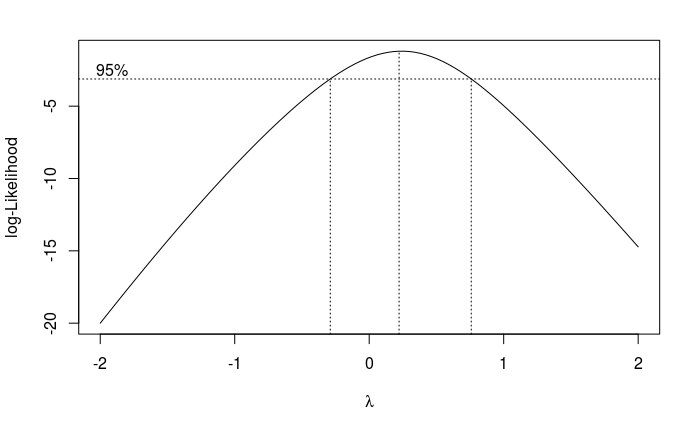

```r
boxcox(y~x,data=madeup)
```

- Lambda is power to transform $y$ by, with 0 having special meaning of “take logs”.
- Anything within the confidence interval (outer dotted lines) supported by data: -0.25 to 0.75 or so.
- Choose a “round” value for lambda.
- Here log or square root (power 0.5) could be justified.
- Try log here.

Make a plot: is relationship between log(y) and x straighter?

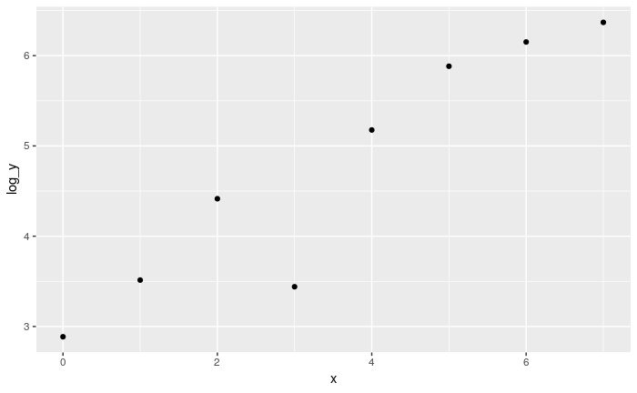

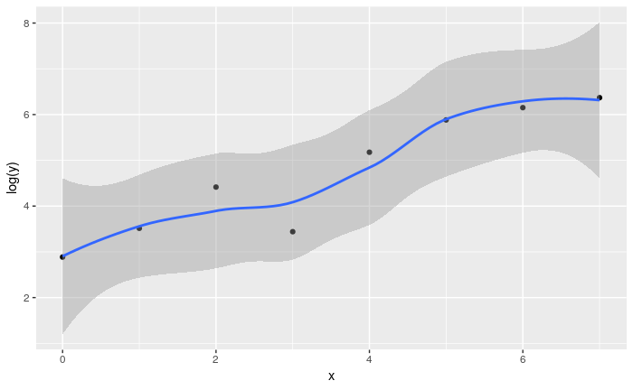

Looks straighter (not obviously curved). So try regression predicting log(y) from x:

```r
madeup.1=lm(log(y)~x, data=madeup)
summary(madeup.1)
```

```
Call:
lm(formula = log(y) ~ x, data = madeup)

Residuals:
     Min       1Q   Median       3Q      Max
-1.02897 -0.06206  0.10333  0.23356  0.46619

Coefficients:
            Estimate Std. Error t value Pr(>|t|)
(Intercept)   2.9085     0.3234   8.995 0.000106 ***
x             0.5202     0.0773   6.731 0.000524 ***
---
Signif. codes:  0 ‘***’ 0.001 ‘**’ 0.01 ‘*’ 0.05 ‘.’ 0.1 ‘ ’ 1

Residual standard error: 0.5009 on 6 degrees of freedom
Multiple R-squared:  0.883, Adjusted R-squared:  0.8636
F-statistic:  45.3 on 1 and 6 DF,  p-value: 0.0005235
```

R-squared high, slope significantly positive. How are the residuals?

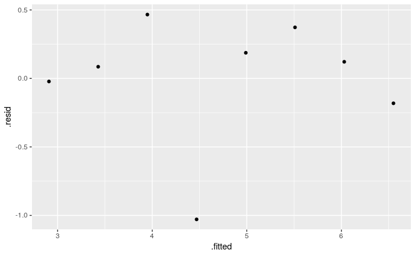

```r
ggplot(madeup.1, aes(x=.fitted, y=.resid))+geom_point()
```

The fourth point (with fitted value 4.5) looks like an outlier now. If this were real data, we would investigate this observation further.